# Windpark Silistea 1 (2011) - 25 MW

Feature Engineering

Author

Jorge A. Thomas

Published

March 31, 2025

**Energy Produced (2023):** 52 GWh https://veronikiwind.ro/en/

**Wind Turbines (WT):** 10 GE (2.5 MW)

**Height of WT:** 100 m

**Rotor Diameter:** 100 m

**Power Output:** 25 MW

“The park has 10 GE turbines of 2.5 MW each, turbines with a tower height of 100 meters and a rotor diameter of 100 meters. The 10 turbines are divided into two groups of 5 turbines; each group being interconnected through 7790m of underground power cables.”

“The electricity production is estimated based on hourly updated weather data (with a time resolution of 15 minutes), provided by external suppliers.”

Source: https://veronikiwind.ro/en/silistea-wind-park/

[figure not shown]

Source: Google Earth

Figure 1: Aerial view of the Silistea 1 windpark.

# OBJECTIVES

- Predict the energy produced of the *Silistea 1* wind park for the first semester of 2024.
- To find a good generalisation of Silistea’s power curve or *signature* in function of the given meteorological and engineered features.

## Some remarks:

- You’re giving me the meteorological data of only *one specific location* or one pair of geographical coordinates. Hence, we assume same wind speeds, temperatures…, for all WT However, in my experience modelling the offshore Baltic-1, this is not true for very big wind farms.
- I will convert energy [kWh] to power [kW] to have a clearer view of the park’s rated output (25 MW).
- I’ll assume given energy values as the *gross* energy yield. I don’t have information about circuit losses and down-times. The latter being possibly deduced in a Wind Speed vs. Power scatter plot.

# PART I: EXPLORATION - EDA

## Querying Data

- Here I check immediately for missing values.

```r
silistea_all <-  read_parquet(here("data", "interim", "Silistea_15min_20220101_20240630_n87457_cols33_null19pct.parquet"))

delta_t <- 0.25 # hours = 15 minutes step.

silistea_all$kW <- silistea_all$kWh / delta_t

# Label "Train" and "Test" data subsets:

silistea_all$dataset <- "train"
silistea_all$dataset[which(is.na(silistea_all$kWh))] <- "test"

print("Available variables:")
```

```
[1] "Available variables:"
```

```r
names(silistea_all)
```

```
 [1] "timestamp"            "t_2m"                 "dew_point_2m"
 [4] "msl_pressure"         "sfc_pressure"         "total_cloud_cover"
 [7] "low_cloud_cover"      "medium_cloud_cover"   "high_cloud_cover"
[10] "precip_1h"            "snow_depth"           "visibility"
[13] "wind_gusts_100m_1h"   "cape"                 "lifted_index"
[16] "wind_speed_u_10m"     "wind_speed_v_10m"     "wind_speed_10m"
[19] "wind_dir_10m"         "wind_speed_u_50m"     "wind_speed_v_50m"
[22] "wind_speed_50m"       "wind_dir_50m"         "wind_speed_u_100m"
[25] "wind_speed_v_100m"    "wind_speed_100m"      "wind_dir_100m"
[28] "wind_speed_u_200m"    "wind_speed_v_200m"    "wind_speed_200m"
[31] "wind_dir_200m"        "relative_humidity_2m" "kWh"
[34] "kW"                   "dataset"
```

- *Meteo* data and *Production* data have different sampling rates => I performed mean-aggregation of the *Meteo* data in order to match the 15-minutes sampling rate of the *production* set.
- Previously, I performed a left-join: Meteo <= Production. Appearing `NA` in Production identified the *test dataset*.

### Physical units:

- Production data in [kWh]
- Temperature in [°C]
- Wind speeds in [m/s] (gusts, ‘u’ and ‘v’ components)
- Pressure in [Pa]
- Cloud cover in [%]
- Precipitation in [mm/m^2]
- Snow depth in [cm]
- visibility in [m]
- cape in [J/kg]
- Lifted index in [K]
- Wind direction in [°] from North (Azimuth)

## Visualising the target

### As a time-series:

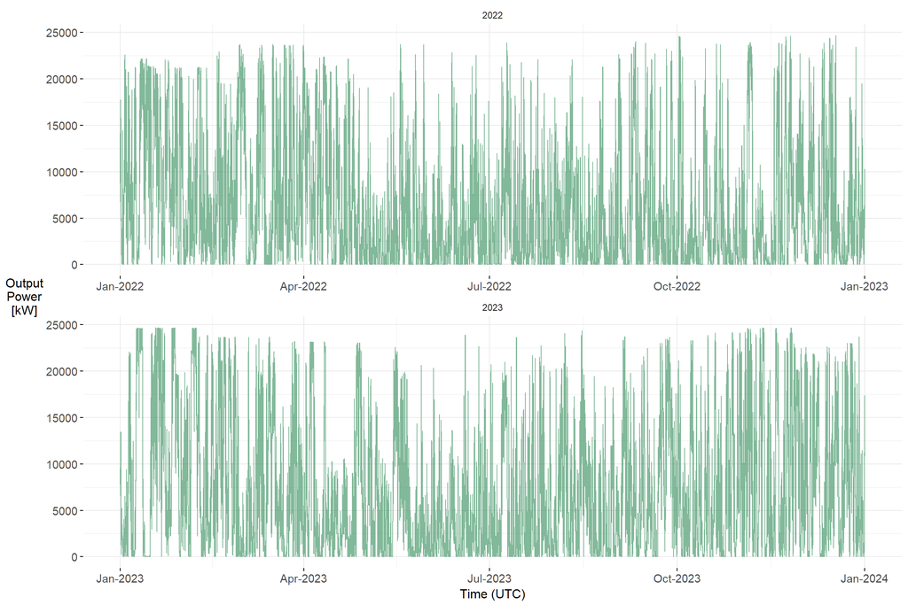

Figure 2: 15-minutes sampled power output during 2022 and 2023.

```r
silistea_all |>
    select(timestamp, kW) |>
    mutate(year = as.factor(year(timestamp))) |>
    filter(year != 2024) |>
    ggplot(aes(x = timestamp)) +
    geom_line(aes(y = kW), colour ="seagreen", alpha =0.6) +
    scale_x_datetime(date_labels = "%b-%Y") +
    labs(y = "Output\nPower\n[kW]", x = "Time (UTC)" ) +
    facet_wrap(~year, ncol=1, scales = "free_x")
```

### As a random variable:

- How well-behaved is the response?

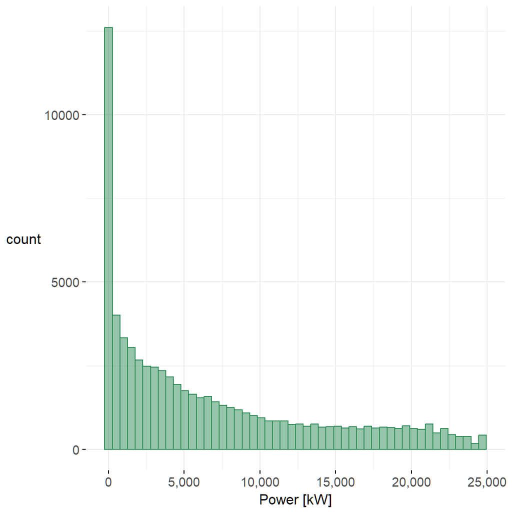

(a) Histogram

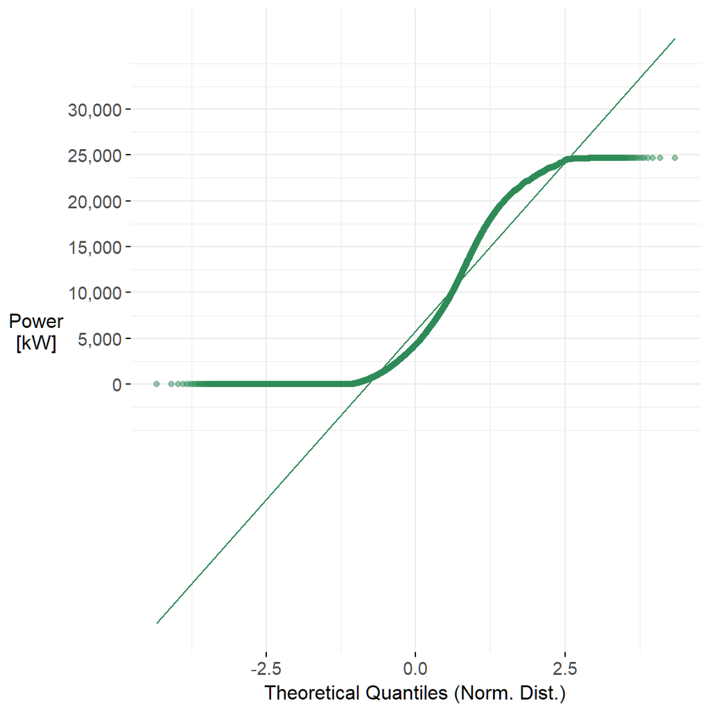

(b) Q-Q Plot

Figure 3: Analysis of the target variable. All the assumptions of OLS and linear regression are broken, as usual.

````markdown
```{r}
#| label: fig-Y
#| message: false
#| warning: false
#| column: body
#| fig-width: 6
#| fig-height: 6
#| fig-cap: "Analysis of the target variable. All the assumptions of OLS and linear regression are broken, as usual."
#| fig-subcap:
#|   - "Histogram"
#|   - "Q-Q Plot"
#| layout-ncol: 2

silistea_all |>
  filter(dataset == "train") |>
  ggplot(aes(x = kW)) +
  geom_histogram(bins = 50, colour = "seagreen", fill = "seagreen", alpha = 0.5) +
  scale_x_continuous(breaks = seq(0, 30000, 5000), labels = scales::comma) +
  labs(x = "Power [kW]")

silistea_all |>
  filter(dataset == "train") |>
  ggplot(aes(sample = kW)) +
  stat_qq(colour = "seagreen", alpha = 0.5) +
  stat_qq_line(colour = "seagreen") +
  scale_y_continuous(breaks = seq(0, 30000, 5000), labels = scales::comma) +
  labs(y = "Power\n[kW]",
       x = "Theoretical Quantiles (Norm. Dist.)")
```
````

- Cut-in speed produces a lot of zeros. An XGBoost regressor could handle this. Otherwise, make a decision rule.
- Suggestion: A Box-Cox transformation adding a constant or apply Yeo-Johnson transformation.

### As aggregated energy yield:

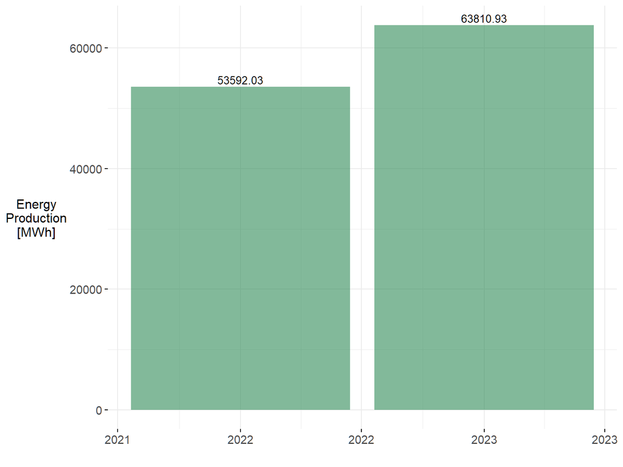

(a) Annual yield.

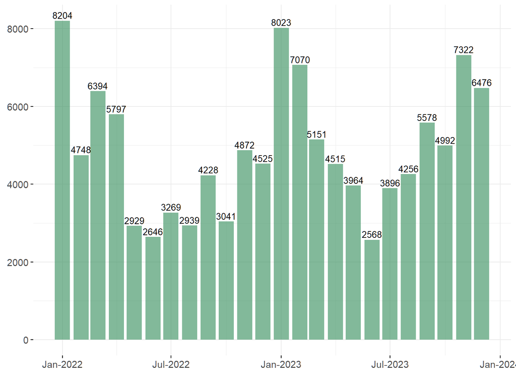

(b) Monthly yield.

Figure 4: Silistea-1 production during 2022 and 2023.

````markdown
```{r}
#| label: fig-e-yield
#| message: false
#| warning: false
#| column: body
#| fig-width: 8
#| fig-height: 6
#| fig-cap: "Silistea-1 production during 2022 and 2023."
#| fig-cap-location: margin
#| fig-subcap:
#|   - "Annual yield."
#|   - "Monthly yield."
#| layout-ncol: 2

# =============  Annual yield =============

annual_yield <- silistea_all |>
    select(timestamp, kWh) |>
    mutate(year = as.factor(year(timestamp))) |>
    filter(year != 2024) |>
    mutate(year = floor_date(timestamp, "year")) |>
    filter(year != as.POSIXct("2024-01-01")) |>
    group_by(year) |>
    summarise(total_energy_kWh = sum(kWh, na.rm = TRUE))

ggplot(annual_yield, aes(x = year, y = total_energy_kWh/1000)) +
  geom_bar(stat = "identity", fill = "seagreen", alpha = 0.6) +
  geom_text(aes(label = round(total_energy_kWh/1000, 2)), vjust = -0.3, size = 3.5) +
  scale_x_datetime(date_labels = "%Y") +
  labs(x = "", y = "Energy\nProduction\n[MWh]")

# ============= Monthly yield ============

monthly_yield <- silistea_all |>
    select(timestamp, kWh) |>
    mutate(year = as.factor(year(timestamp))) |>
    filter(year != 2024) |>
    mutate(month = floor_date(timestamp, "month")) |>
    group_by(month) |>
    summarise(total_energy_kWh = sum(kWh, na.rm = TRUE))

ggplot(monthly_yield, aes(x = month, y = total_energy_kWh/1000)) +
  geom_bar(stat = "identity", fill = "seagreen", alpha = 0.6) +
  geom_text(aes(label = round(total_energy_kWh/1000, 0)), vjust = -0.3, size = 3.5) +
  scale_x_datetime(date_labels = "%b-%Y") +
  labs(x = "", y = "")
```
````

- According to the data supplied, the webpage https://veronikiwind.ro/en/ has an error. The 52000 MWh were produced in 2022 and not in 2023.
- Yearly seasonality is easy discovered looking at the energy produced monthly.
- Dobrogea seems pretty windy in January!

# PART 2: FEATURE ENGINEERING AND ANALYSIS

As engineer, I already know what the most importan predictors are.

## Add Humid Air Density as Feature

````markdown
```{r}
silistea_all$humid_air_density <- calc_humid_air_density(silistea_all$t_2m, silistea_all$relative_humidity_2m/100, silistea_all$sfc_pressure/100) # Pa -> mbar
```
````

- Since the relationship *height vs. wind speed* is not linear, let’s interpolate wind speed with *splines* to get and approximated value at 150 metres.
- Then, average wind speeds in the range of 50 to 150 metres, i.e., Feat. reduction to bypass collinearity.

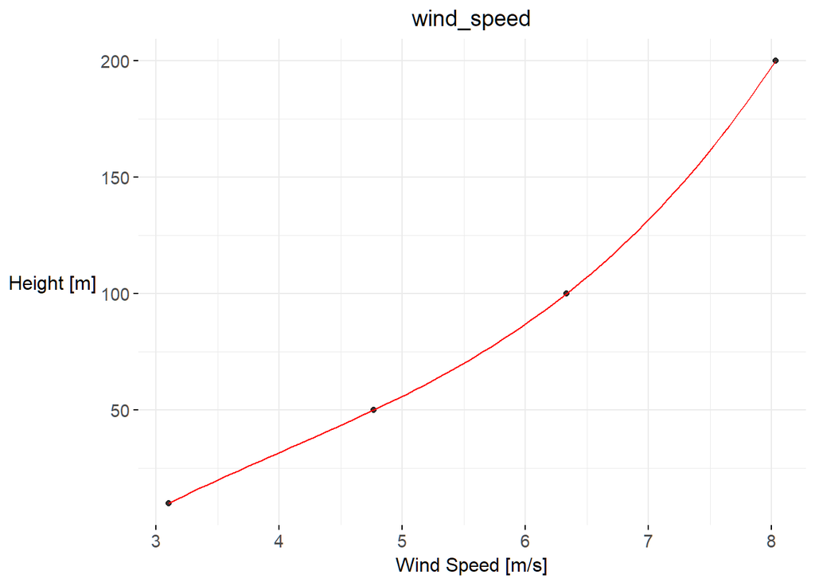

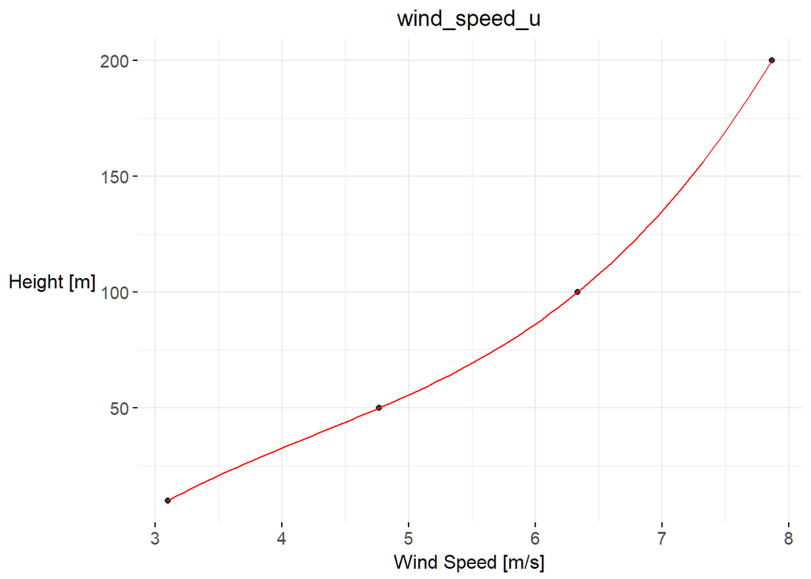

````markdown
```{r}
# TODO Write a function for the following:

# =================== wind speeds ===================

wind_speeds <- silistea_all |>
  select(wind_speed_10m, wind_speed_50m, wind_speed_100m, wind_speed_200m) |>
  mutate(wind_speed_150m  = NA) |>
  relocate(wind_speed_150m, .before = wind_speed_200m)


ggplot(data = data.frame(windspeeds = t(wind_speeds[1,]),
                          height = c(10, 50, 100, 150, 200)),
        aes(x = windspeeds, y = height)) +
        geom_point(alpha = 0.8) +
        geom_smooth(method = "lm", formula =  y ~ splines::bs(x, 3), colour = "red", linewidth = 0.5, alpha = 0.5) +
        labs(title = "wind_speed", y = "Height [m]", x = "Wind Speed [m/s]")
```
```{r}
# Generate New Feat. wind_speed_150m

for (i in 1:nrow(wind_speeds)) {

  wind_speeds$wind_speed_150m[i] <- spline(c(10, 50, 100, 150, 200), wind_speeds[i,], xout = 150)$y

}

 # Add new Feat. to DF

silistea_all$wind_speed_150m <- wind_speeds$wind_speed_150m

# Average wind speeds

silistea_all <- silistea_all |>
  mutate(wind_speed_avg = (wind_speed_50m + wind_speed_100m + wind_speed_150m)/3)


# =================== u component wind speeds ===================

wind_speeds_u <- silistea_all |>
  select(wind_speed_u_10m, wind_speed_u_50m, wind_speed_u_100m, wind_speed_u_200m) |>
  mutate(wind_speed_u_150m  = NA) |>
  relocate(wind_speed_u_150m, .before = wind_speed_u_200m)


ggplot(data = data.frame(windspeeds_u = t(wind_speeds_u[1,]), height = c(10, 50, 100, 150, 200)),
       aes(x = windspeeds_u, y = height)) +
       ggtitle("wind_speed_u") +
       geom_point(alpha = 0.8) +
       geom_smooth(method = "lm", formula =  y ~ splines::bs(x, 3), colour = "red", linewidth = 0.5, alpha = 0.5) +
       labs(y = "Height [m]", x = "Wind Speed [m/s]")
```
```{r}
# Generate New Feat. wind_speed_u_150m

for (i in 1:nrow(wind_speeds_u)) {

  wind_speeds_u$wind_speed_u_150m[i] <- spline(c(10, 50, 100, 150, 200), wind_speeds_u[i,], xout = 150)$y

}

# Add new Feat. to DF

silistea_all$wind_speed_u_150m <- wind_speeds_u$wind_speed_u_150m

# Average wind_speeds_u

silistea_all <- silistea_all |>
  mutate(wind_speed_u_avg = (wind_speed_u_50m + wind_speed_u_100m + wind_speed_u_150m)/3)


# arrow::write_parquet(silistea_all, here("data", "interim", "Silistea_15min_20220101_20240630_n87457_cols40_All_Feats.parquet"))


# Drop

silistea_all <- silistea_all |>
  select(-c(wind_speed_10m, wind_speed_50m, wind_speed_100m, wind_speed_150m, wind_speed_200m))


silistea_all <- silistea_all |>
  select(-c(wind_speed_u_10m, wind_speed_u_50m, wind_speed_u_100m, wind_speed_u_150m, wind_speed_u_200m))
```
````

## Searching for collinearities and simple correlations

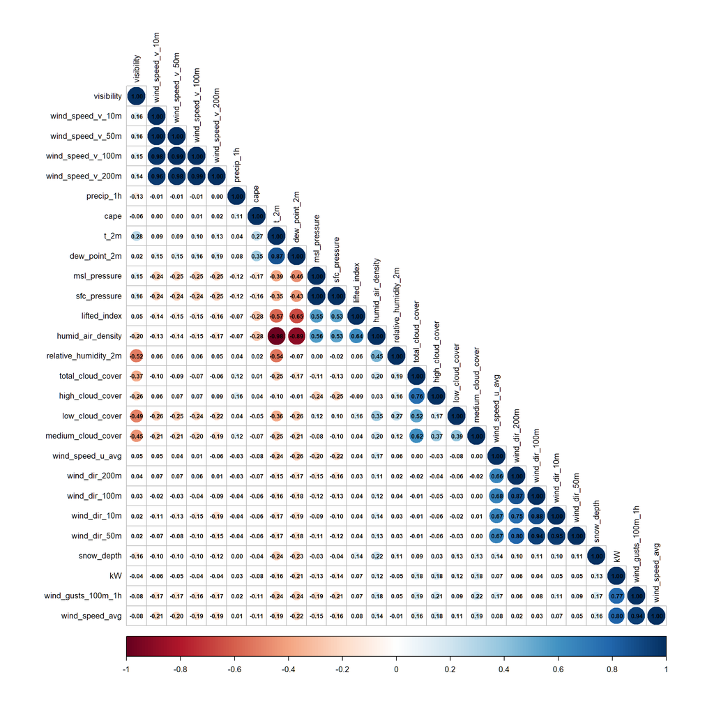

````markdown
```{r}
#| label: fig-num-corr
#| fig-width: 12
#| fig-height: 12
#| fig-cap: The Pearson's correlation of features shows high presence of multicollinearity (blue triangles).
#| warning: false
#| message: false

silistea_all |>
  filter(dataset == "train") |>
  select(-c(timestamp, dataset, , kWh)) |>
  cor(method = "pearson") |>
  corrplot(type = "lower", method = "circle", insig = 'blank', order = "hclust", diag = TRUE,
  tl.col="black", tl.cex = 0.8, addCoef.col = 'black', number.cex = 0.6)
```
````

- Because the rotor diameter is 100 metres (r = 50 metres) and the tower is 100 metres, the wind speed **seen** by the blades ranges from 50 m to 150 m.

### Eleminate highly correlated features and low info ones

- Drop very low info columns: `precip_1h`, `cape`, `snow_depth`.

## Screening of variable importance

- To which extent each of the original features reduce the uncertainty of the response `kW`?

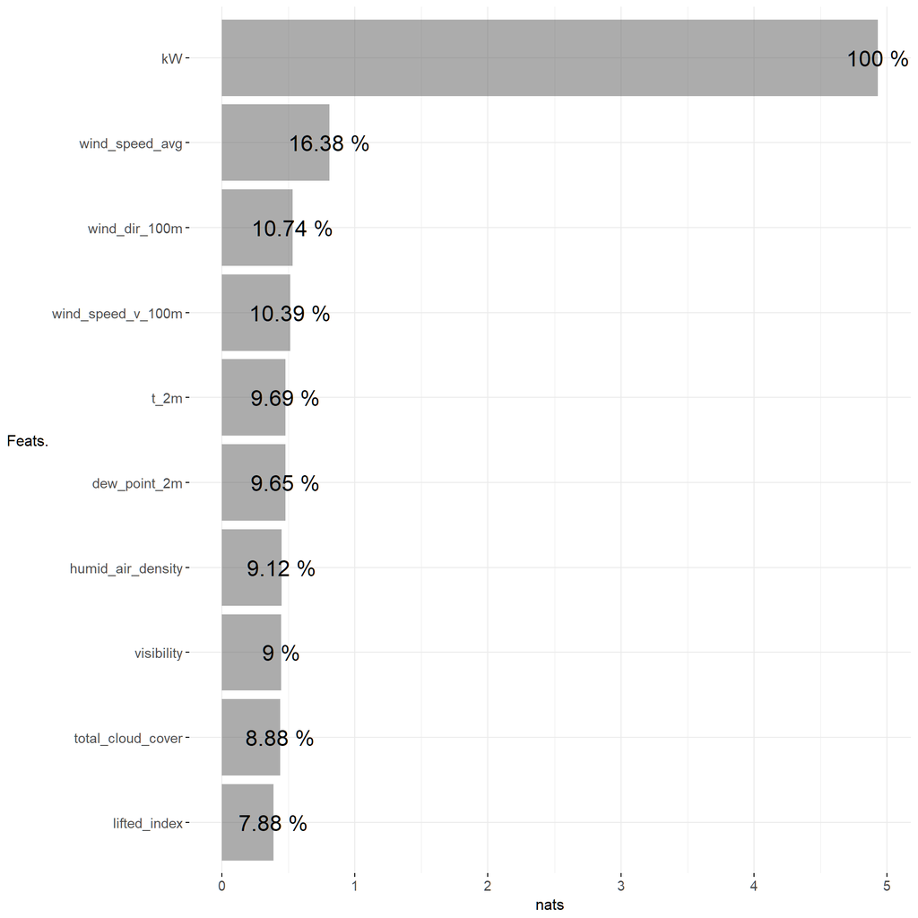

Figure 7: Mutual information criterion.

````markdown
```{r}
#| label: fig-num-mi
#| fig-width: 10
#| fig-height: 10
#| fig-cap: "Mutual information criterion."
#| fig-cap-location: margin

# "calc_mi" is a function I wrote in my lib.

mi_y_X <- silistea_redux |>
  filter(dataset == "train") |>
  select(-c(timestamp, dataset, kWh)) |>
  calc_mi_score(target = "kW")

ggplot(data = mi_y_X, aes(x = nats, y = fct_reorder(Variable, nats))) +
    geom_col(alpha = 0.5) +
    geom_text(aes(label = paste(round(Percent, 2), "%")), size = 6) +
    labs(y = "Feats.") +
    theme(legend.position = "none")
```
````

## Visualising distributions of predictors

- Main Feature: `wind_speed_avg`

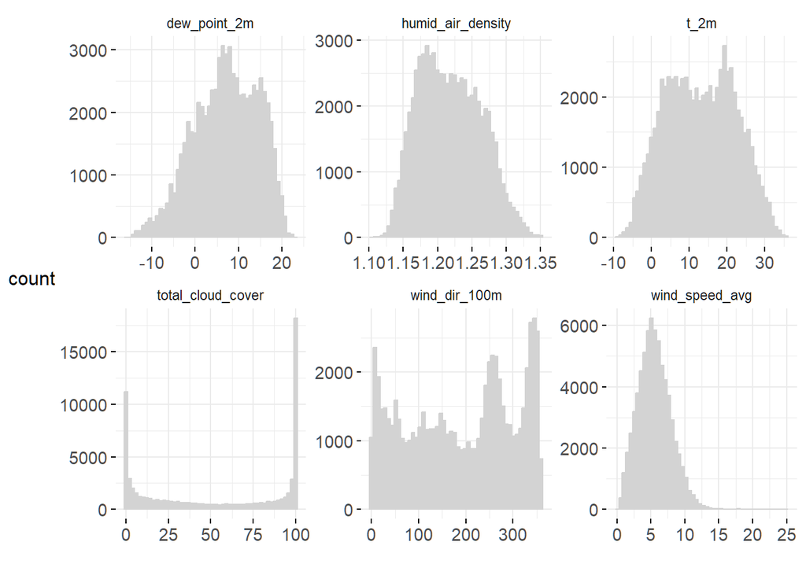

Figure 8: Sample of skewed predictors.

````markdown
```{r}
#| label: fig-skewed-feats
#| fig-cap: "Sample of skewed predictors."

silistea_redux |>
  filter(dataset == "train") |>
  select(c(t_2m, dew_point_2m, wind_dir_100m, humid_air_density, total_cloud_cover, wind_speed_avg)) |>
  pivot_longer(t_2m:wind_speed_avg) |>
  ggplot(aes(x = value)) +
  geom_histogram(bins = 50, colour = "lightgrey", fill = "lightgrey") +
  labs(x = "") +
  facet_wrap(~name, scales = "free")
```
````

- It will be convenient to apply a transformation to try to normalise the feature matrix.
- Wind speeds above 10 m/s are rare.

## Visualising main predictor vs. response

- This will show the effect of ten aggregated Power Curves of WTs under slightly different conditions.
- The main idea is to find the particular *power sigmoid signature”* of the wind park.

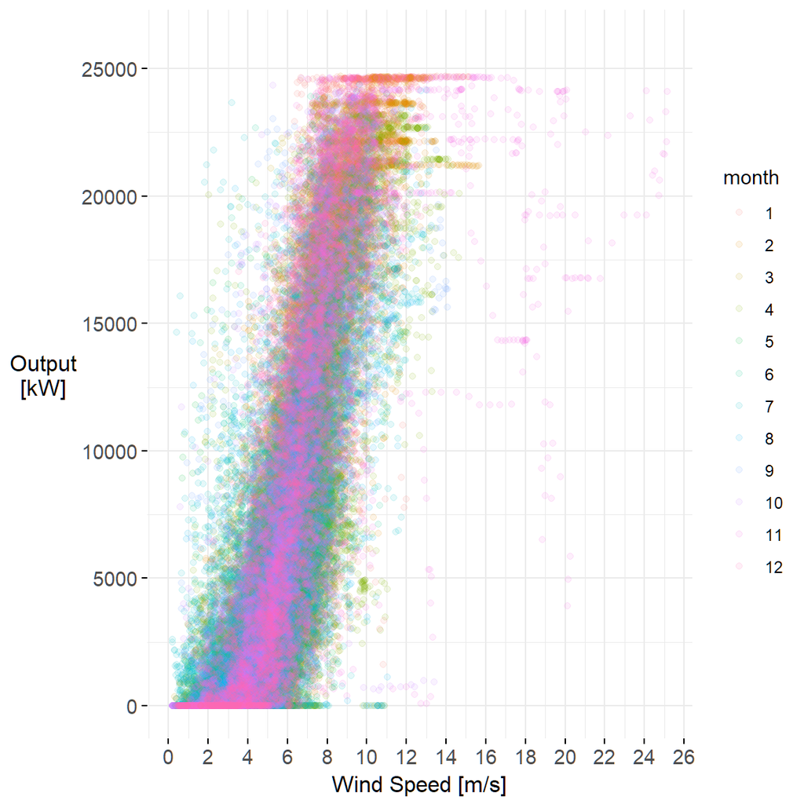

(a) Scatter plot.

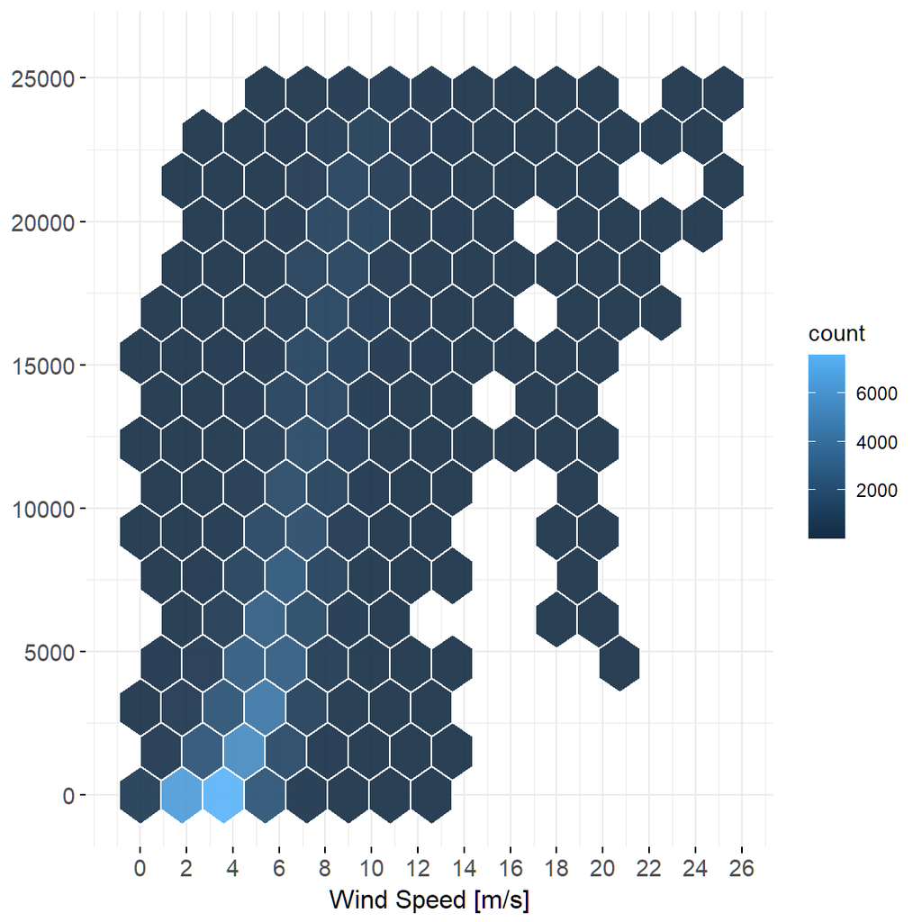

(b) Hexagonal bins plot.

Figure 9: Looking for the wind farm power curve.

````markdown
```{r}
#| label: fig-scatter-plots
#| message: false
#| warning: false
#| column: body
#| fig-width: 6
#| fig-height: 6
#| fig-cap: 'Looking for the wind farm power curve.'
#| cap-location: margin
#| fig-subcap:
#|   - "Scatter plot."
#|   - "Hexagonal bins plot."
#| layout-ncol: 2

# ============== Scatter plot ==============

silistea_redux |>
  filter(dataset == "train") |>
  select(timestamp, wind_speed_avg, t_2m, dew_point_2m, kW) |>
  mutate(month = as.factor(month(timestamp))) |>

  ggplot(aes(x = wind_speed_avg, y = kW))  +
  scale_x_continuous(breaks = seq(0, 30, 2)) +
  scale_y_continuous(breaks = seq(0, 30000, 5000), limits = c(0, 26000)) +
  geom_point(aes(colour = month), alpha = 0.1) +
  # geom_point(aes(colour = t_2m), alpha = 0.1) +
  labs(x = "Wind Speed [m/s]", y = "Output\n[kW]" )


# =========== Hexagonal bins plot ============

silistea_redux |>
  filter(dataset == "train") |>

  ggplot(aes(x = wind_speed_avg, y = kW)) +
  scale_x_continuous(breaks = seq(0, 30, 2), limits = c(-1, 26) ) +
  scale_y_continuous(breaks = seq(0, 30000, 5000), limits = c(-500, 26000)) +
  geom_hex(bins = 15, colour = "white", alpha = 0.9) +
  labs(x = "Wind Speed [m/s]", y = "Output\n[kW]" ) +
  theme(axis.title.y = element_blank(), legend.position = "right")
```
````